# STAT 425 - HW5

Josh Janda

05 April, 2020

```r
library(tidyverse)
library(faraway)
library(nlme)
library(lmtest)
library(splines)
library(MASS)
```

## Problem 1.

The aatemp data come from the U.S. Historical Climatological Network. They are the annual mean temperatures (in degrees F) in Ann Arbor Michigan, going back about 150 years.

### A.

Is there a linear trend?

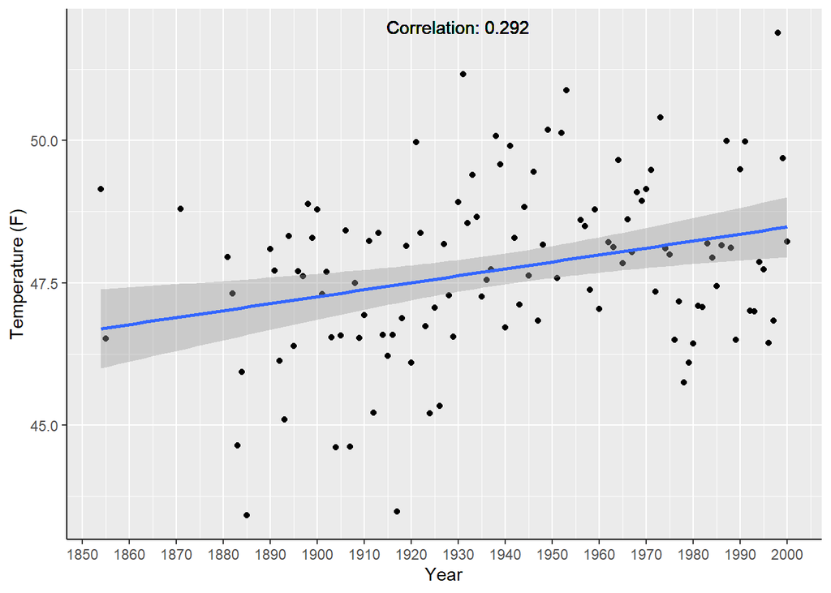

```r
linear_mod = lm(temp ~ year, data = aatemp)
linear_cor = cor(aatemp$year, aatemp$temp)
cor_label = paste('Correlation:', round(linear_cor, 3), sep = ' ')

ggplot(data = aatemp, aes(x = year, y = temp)) +
  geom_point() +
  geom_text(label = cor_label, x = 1930, y = 52) +
  geom_smooth(method = 'lm', formula = y ~ x) +
  labs(x = 'Year', y = 'Temperature (F)') +
  theme(axis.line = element_line(color = 'black')) +
  scale_x_continuous(breaks = scales::pretty_breaks(n = 20))
```

Looking at the plot above, there seems to be somewhat of a linear trend. We can see that there is a correlation of .292 which demonstrates a linear trend of the data. Being time series data, this linear trend I am somewhat skeptical of due to possible correlation between error over time.

### B.

Observations in successive years may be correlated. Fit the model that estimates this correlation. Does this change your opinion about the trend?

```r
dwtest(lm(temp ~ year, data = aatemp))
```

```
##
##  Durbin-Watson test
##
## data:  lm(temp ~ year, data = aatemp)
## DW = 1.6177, p-value = 0.01524
## alternative hypothesis: true autocorrelation is greater than 0
```

Looking at the output above, we can reject the null hypothesis that there errors are not correlated. Therefore, there is autocorrelation in our model which further signifies that there is a linear trend in the data. Let’s create a new model with an AR term of 2.

```r
ar2 = gls(temp ~ year, correlation = corARMA(p=2), data=aatemp)
summary(ar2)
```

```
## Generalized least squares fit by REML
##   Model: temp ~ year
##   Data: aatemp
##        AIC      BIC    logLik
##   427.1146 440.7516 -208.5573
##
## Correlation Structure: ARMA(2,0)
##  Formula: ~1
##  Parameter estimate(s):
##      Phi1      Phi2
## 0.1795324 0.1405597
##
## Coefficients:
##                 Value Std.Error  t-value p-value
## (Intercept) 24.893919 10.232642 2.432795  0.0166
## year         0.011785  0.005275 2.234200  0.0274
##
##  Correlation:
##      (Intr)
## year -1
##
## Standardized residuals:
##        Min         Q1        Med         Q3        Max
## -2.7080508 -0.6239048 -0.0494172  0.6686955  2.3797429
##
## Residual standard error: 1.479033
## Degrees of freedom: 115 total; 113 residual
```

```r
intervals(ar2)
```

```
## Approximate 95% confidence intervals
##
##  Coefficients:
##                   lower        est.       upper
## (Intercept) 4.621210039 24.89391876 45.16662749
## year        0.001334604  0.01178476  0.02223491
## attr(,"label")
## [1] "Coefficients:"
##
##  Correlation structure:
##            lower      est.    upper
## Phi1 -0.01365823 0.1795324 0.278903
## Phi2 -0.05051072 0.1405597 0.321704
## attr(,"label")
## [1] "Correlation structure:"
##
##  Residual standard error:
##    lower     est.    upper
## 1.280948 1.479033 1.707749
```

We do see that both the Phi Coefficients are not significant, so there is somewhat of a contradiction. However, I do believe there is somewhat of a linear trend in the data.

Overall, with the AR(2) model, my opinion stays that there is a linear trend in the data. There is an obvious linear trend where as time increases so does the temperature on average.

### C.

```r
degree_10_mod = lm(temp ~ I(year) + I(year^2) + I(year^3) +
                     I(year^4) + I(year^5) + I(year^6) + I(year^7) +
                     I(year^8) + I(year^9) + I(year^10), data=aatemp)


back_mod = step(degree_10_mod, direction = 'backward', trace=10)
```

```
## Start:  AIC=83.25
## temp ~ I(year) + I(year^2) + I(year^3) + I(year^4) + I(year^5) +
##     I(year^6) + I(year^7) + I(year^8) + I(year^9) + I(year^10)
##
##
## Step:  AIC=83.25
## temp ~ I(year) + I(year^2) + I(year^3) + I(year^4) + I(year^5) +
##     I(year^6) + I(year^7) + I(year^8) + I(year^9)
##
##
## Step:  AIC=83.25
## temp ~ I(year) + I(year^2) + I(year^3) + I(year^4) + I(year^5) +
##     I(year^6) + I(year^7) + I(year^8)
##
##
## Step:  AIC=83.25
## temp ~ I(year) + I(year^2) + I(year^3) + I(year^4) + I(year^5) +
##     I(year^6) + I(year^8)
##
##
## Step:  AIC=83.25
## temp ~ I(year) + I(year^2) + I(year^3) + I(year^4) + I(year^5) +
##     I(year^8)
##
##
## Step:  AIC=83.25
## temp ~ I(year) + I(year^2) + I(year^3) + I(year^4) + I(year^8)
##
##             Df Sum of Sq    RSS    AIC
## <none>                   213.68 83.249
## - I(year)    1    11.093 224.78 87.069
## - I(year^2)  1    11.155 224.84 87.101
## - I(year^3)  1    11.217 224.90 87.133
## - I(year^4)  1    11.278 224.96 87.164
## - I(year^8)  1    11.512 225.19 87.284
```

```r
back_r2 = summary(back_mod)$r.sq

summary(back_mod)
```

```
##
## Call:
## lm(formula = temp ~ I(year) + I(year^2) + I(year^3) + I(year^4) +
##     I(year^8), data = aatemp)
##
## Residuals:
##     Min      1Q  Median      3Q     Max
## -3.7126 -0.9175 -0.1441  0.9905  3.2313
##
## Coefficients:
##               Estimate Std. Error t value Pr(>|t|)
## (Intercept) -7.049e+07  2.972e+07  -2.372   0.0194 *
## I(year)      1.676e+05  7.047e+04   2.379   0.0191 *
## I(year^2)   -1.526e+02  6.396e+01  -2.385   0.0188 *
## I(year^3)    6.347e-02  2.653e-02   2.392   0.0185 *
## I(year^4)   -1.031e-05  4.299e-06  -2.399   0.0182 *
## I(year^8)    1.074e-20  4.432e-21   2.423   0.0170 *
## ---
## Signif. codes:  0 '***' 0.001 '**' 0.01 '*' 0.05 '.' 0.1 ' ' 1
##
## Residual standard error: 1.4 on 109 degrees of freedom
## Multiple R-squared:  0.1955, Adjusted R-squared:  0.1586
## F-statistic: 5.298 on 5 and 109 DF,  p-value: 0.0002141
```

Using backward regression, we end up only with polynomial variables of 1, 2, 3, 4, and 8. Let’s go ahead and plot this fit on top of the data.

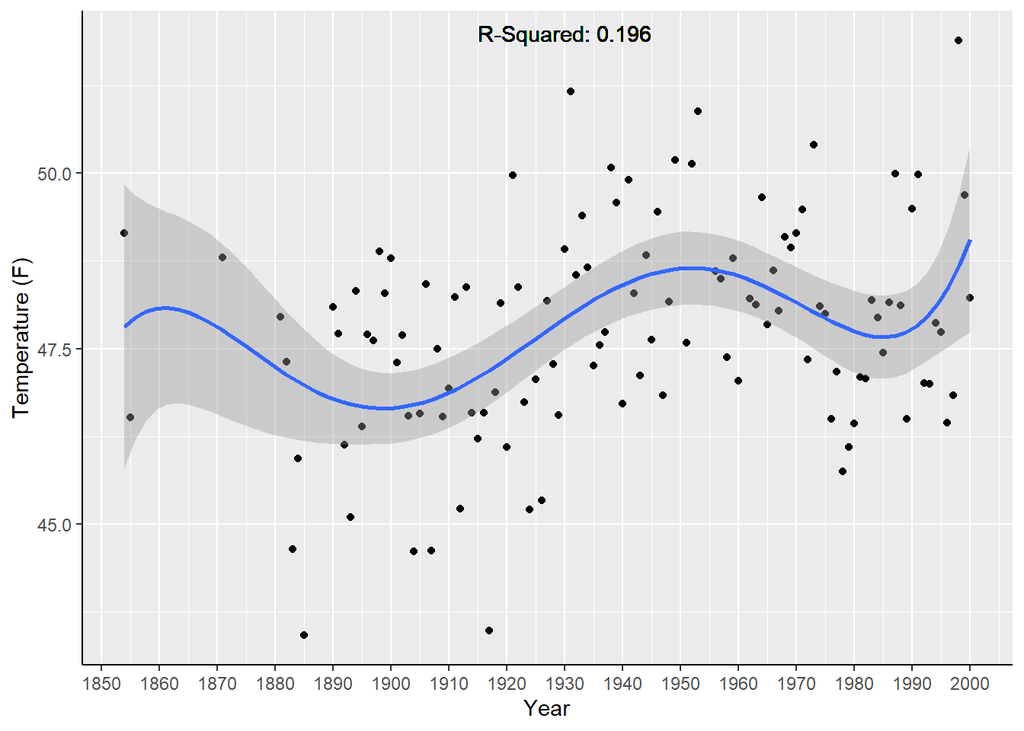

```r
ggplot(data = aatemp, aes(x = year, y = temp)) +
  geom_point() +
  geom_text(label = paste("R-Squared:", round(back_r2, 3), sep=' '), x = 1930, y = 52) +
  geom_smooth(method = 'lm',
              formula = y ~ x + I(x^2) + I(x^3) + I(x^4) + I(x^8)) +
  labs(x = 'Year', y = 'Temperature (F)') +
  theme(axis.line = element_line(color = 'black')) +
  scale_x_continuous(breaks = scales::pretty_breaks(n = 20))
```

Looking at the plot above, this model seems to fit the data similar to the linear model but with higher order terms. To fully compare, let’s predict on this model and the original and compare RMSE’s.

```r
rmse = function(actual, fitted) {

  sqrt(sum((actual - fitted)^2) / length(actual))

}

rmse_linear = rmse(aatemp$temp, linear_mod$fitted.values)
rmse_d10 = rmse(aatemp$temp, back_mod$fitted.values)

data.frame(RMSE = c(Linear = rmse_linear, Backward = rmse_d10))
```

```
##              RMSE
## Linear   1.453452
## Backward 1.363124
```

Looking at the table above, the backward model obtains a slightly lower root mean square error. This tells me that this model fits the data better and provides more accurate predicted values.

### D.

Make a cubic spline fit with six basis functions evenly spaced on the range. Plot the fit in comparison with the previous fit. Does this model fit better than the selected polynomial model?

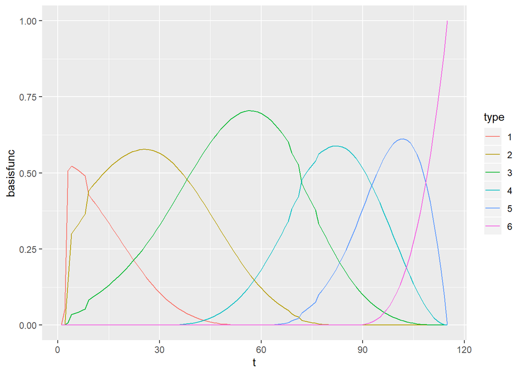

```r
spl = bs(aatemp$year, df = 6)

mydf =  6
n = dim(spl)[1]
tmpdata = data.frame(t = rep(1:n, mydf),
                     basisfunc=as.vector(spl),
                     type=as.factor(rep(1:mydf, each=n)))
ggplot(tmpdata, aes(x=t, y=basisfunc, color=type)) +
  geom_path()
```

The plot above shows each basis function at each observation and it’s respective value. Let’s go ahead and fit the model.

```r
spl_fit = lm(temp ~ bs(year, df = 6), data = aatemp)
spl_r2 = summary(spl_fit)$r.sq
summary(spl_fit)
```

```
##
## Call:
## lm(formula = temp ~ bs(year, df = 6), data = aatemp)
##
## Residuals:
##     Min      1Q  Median      3Q     Max
## -3.6561 -0.9270 -0.1545  0.9551  3.2158
##
## Coefficients:
##                   Estimate Std. Error t value Pr(>|t|)
## (Intercept)        47.8876     1.0083  47.493   <2e-16 ***
## bs(year, df = 6)1  -0.2200     1.8374  -0.120   0.9049
## bs(year, df = 6)2  -2.3188     1.2635  -1.835   0.0692 .
## bs(year, df = 6)3   0.9948     1.2497   0.796   0.4278
## bs(year, df = 6)4   0.8136     1.2814   0.635   0.5268
## bs(year, df = 6)5  -1.1798     1.3381  -0.882   0.3799
## bs(year, df = 6)6   1.3563     1.2623   1.074   0.2850
## ---
## Signif. codes:  0 '***' 0.001 '**' 0.01 '*' 0.05 '.' 0.1 ' ' 1
##
## Residual standard error: 1.401 on 108 degrees of freedom
## Multiple R-squared:  0.2017, Adjusted R-squared:  0.1573
## F-statistic: 4.547 on 6 and 108 DF,  p-value: 0.0003774
```

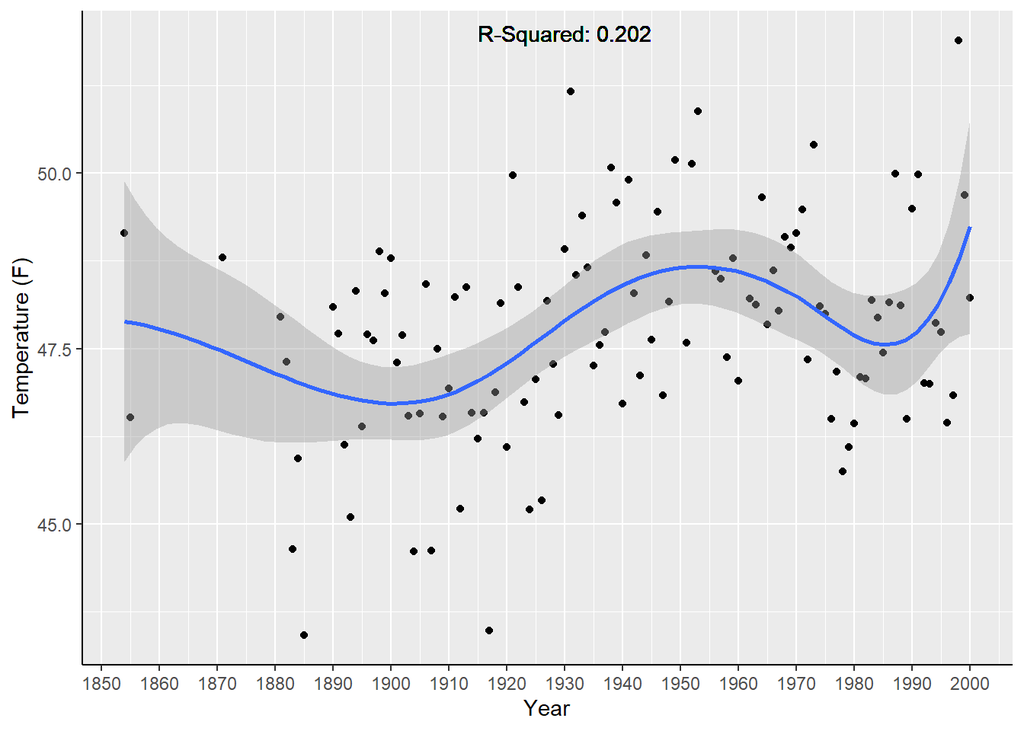

```r
ggplot(data = aatemp, aes(x = year, y = temp)) +
  geom_point() +
  geom_text(label = paste("R-Squared:", round(spl_r2, 3), sep=' '), x = 1930, y = 52) +
  geom_smooth(method = 'lm',
              formula = y ~ bs(x, df = 6)) +
  labs(x = 'Year', y = 'Temperature (F)') +
  theme(axis.line = element_line(color = 'black')) +
  scale_x_continuous(breaks = scales::pretty_breaks(n = 20))
```

Looking at the plot above, this model seems to fit slightly better than the polynomial model judging by the $R^2$ as well as the fitted line. Let’s plot both together to see where they differ as they look extremely similar.

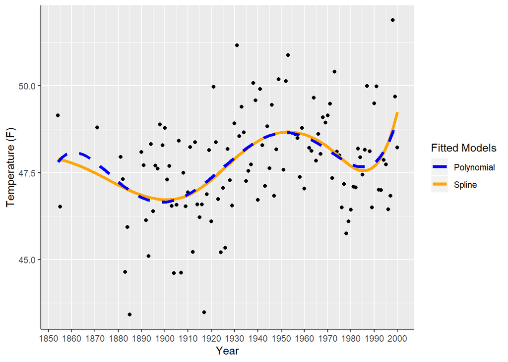

```r
ggplot(data = aatemp, aes(x = year, y = temp)) +
  geom_point() +
  geom_smooth(method = 'lm',
              formula = y ~ bs(x, df = 6),
              se = FALSE, lwd = 1.5, aes(color = 'Spline')) +
  geom_smooth(method = 'lm', linetype = 'dashed',
              formula = y ~ x + I(x^2) + I(x^3) + I(x^4) + I(x^8),
              se = FALSE, lwd = 1.5, aes(color = ('Polynomial'))) +
  labs(x = 'Year', y = 'Temperature (F)', color = 'Fitted Models') +
  theme(axis.line = element_line(color = 'black')) +
  scale_x_continuous(breaks = scales::pretty_breaks(n = 20)) +
  scale_color_manual(values = c('blue', 'orange'))
```

Looking at the plot above, we see that the fitted lines are almost identical outside of the first few years of data. Once the data is at ~1880, the fitted lines become identical. This tells me that the polynomial terms used work well to model the data, as well as using six basis functions.

Overall, I still believe this data follows a linear trend due to autocorrelation but can also be accurately modeled using splines or polynomial terms.

## Problem 2.

Using the infmort data, find a model for the infant mortality in terms of the other variables. Be alert for transformations and unusual points. Interpret your model by explaining what the regression parameter estimates mean.

Let’s first look at the data.

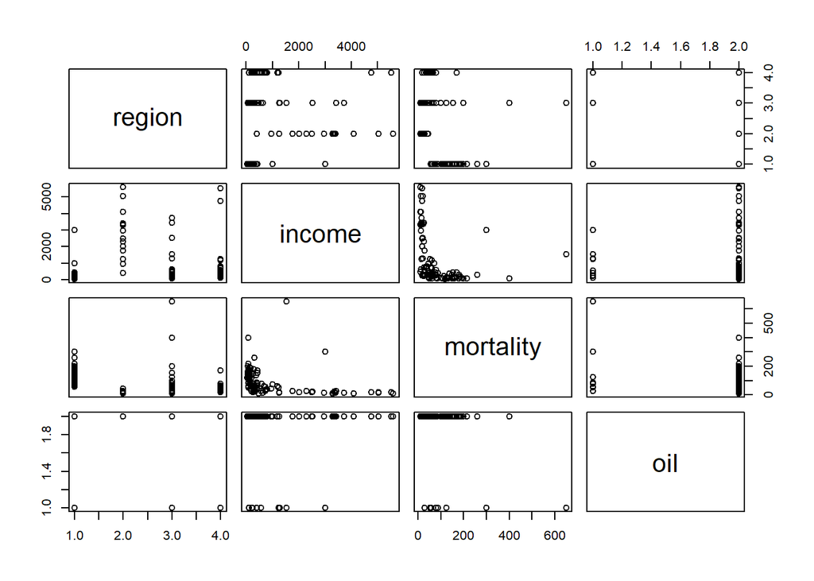

```r
pairs(infmort)
```

All predictors except income are categorical. There is no real interpretation of those plots. For income, there seems to be a -log(income) relationship between mortality. Let’s try the first linear model.

```r
inf_mod1 = lm(mortality ~ ., data = infmort)
summary(inf_mod1)
```

```
##
## Call:
## lm(formula = mortality ~ ., data = infmort)
##
## Residuals:
##     Min      1Q  Median      3Q     Max
## -156.00  -32.20   -4.44   13.65  488.82
##
## Coefficients:
##                     Estimate Std. Error t value Pr(>|t|)
## (Intercept)        2.152e+02  2.974e+01   7.234 1.19e-10 ***
## regionEurope      -1.015e+02  3.073e+01  -3.303 0.001351 **
## regionAsia        -4.589e+01  2.014e+01  -2.278 0.024977 *
## regionAmericas    -8.365e+01  2.180e+01  -3.837 0.000224 ***
## income            -5.290e-03  7.404e-03  -0.714 0.476685
## oilno oil exports -7.834e+01  2.891e+01  -2.710 0.007992 **
## ---
## Signif. codes:  0 '***' 0.001 '**' 0.01 '*' 0.05 '.' 0.1 ' ' 1
##
## Residual standard error: 77.36 on 95 degrees of freedom
##   (4 observations deleted due to missingness)
## Multiple R-squared:  0.3105, Adjusted R-squared:  0.2742
## F-statistic: 8.556 on 5 and 95 DF,  p-value: 1.015e-06
```

The first model is a completely linear model using all variables. All predictors are significant outside of income. Let’s try transforming the income variable by visualizing the relationship between mortality and income.

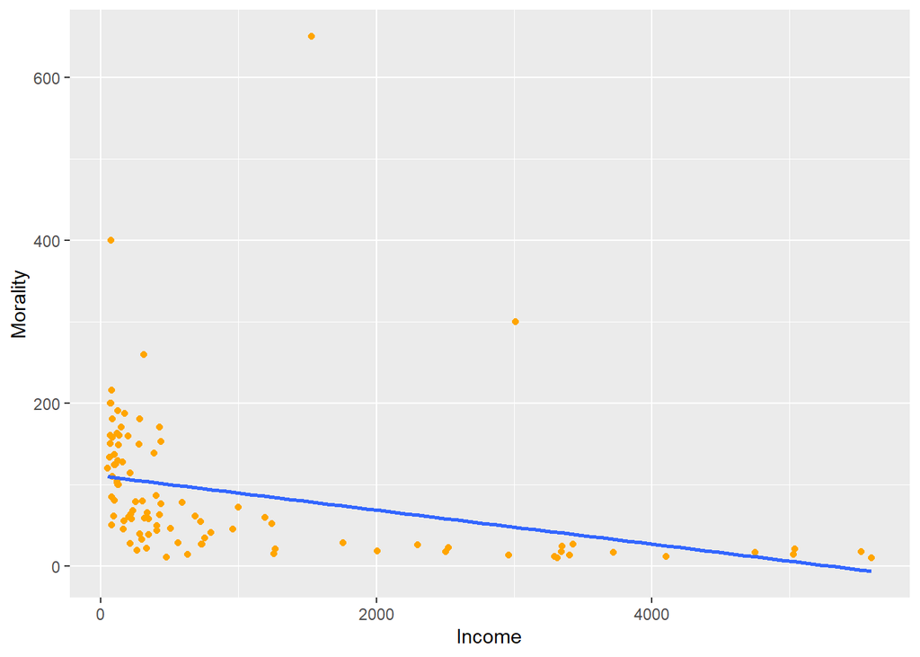

```r
ggplot(data = infmort, aes(x = income, y = mortality)) +
  geom_point(color = 'orange') +
  geom_smooth(method = 'lm', formula = y ~ x, se = FALSE) +
  labs(x = 'Income', y = 'Morality')
```

Looking at the graph above and the fitted line, I can see that using income itself is not a good predictor. I do believe that possibly adding the term -log(income) will fit the data better.

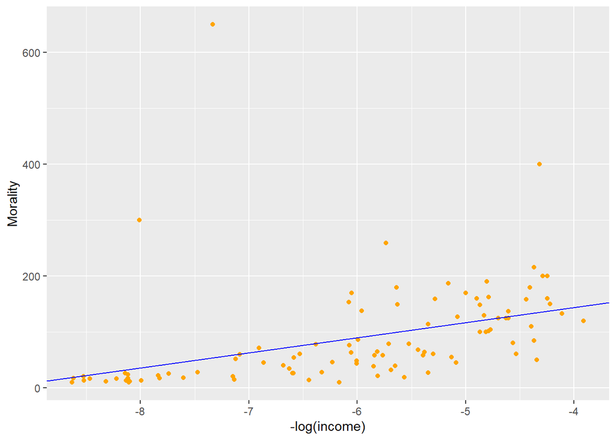

```r
log_income = lm(mortality ~ I(-log(income)), data = infmort)
ggplot(data = infmort, aes(x = -log(income), y = mortality)) +
  geom_point(color = 'orange') +
  geom_abline(intercept = coef(log_income)[1], slope = coef(log_income)[2], color = 'blue') +
  labs(x = '-log(income)', y = 'Morality')
```

Looking at the plot above, transforming income to -log(income) creates a much better fit between mortality and income. Let’s add this term rather than income to the model and see if our model improves.

```r
inf_mod2 = lm(mortality ~ region + oil + I(-log(income)), data = infmort)
summary(inf_mod2)
```

```
##
## Call:
## lm(formula = mortality ~ region + oil + I(-log(income)), data = infmort)
##
## Residuals:
##     Min      1Q  Median      3Q     Max
## -157.89  -34.33   -3.33   14.68  497.00
##
## Coefficients:
##                   Estimate Std. Error t value Pr(>|t|)
## (Intercept)        276.479     57.696   4.792 6.09e-06 ***
## regionEurope       -84.334     33.411  -2.524  0.01326 *
## regionAsia         -41.095     20.508  -2.004  0.04793 *
## regionAmericas     -72.369     24.011  -3.014  0.00331 **
## oilno oil exports  -84.558     29.290  -2.887  0.00482 **
## I(-log(income))     11.234      8.666   1.296  0.19799
## ---
## Signif. codes:  0 '***' 0.001 '**' 0.01 '*' 0.05 '.' 0.1 ' ' 1
##
## Residual standard error: 76.89 on 95 degrees of freedom
##   (4 observations deleted due to missingness)
## Multiple R-squared:  0.3188, Adjusted R-squared:  0.283
## F-statistic: 8.894 on 5 and 95 DF,  p-value: 5.906e-07
```

It is possible that the $y$ variable itself needs to be transformed. I will perform a box-cox transformation to see if that is the case.

```r
inf_mod3 = boxcox(inf_mod1)
```

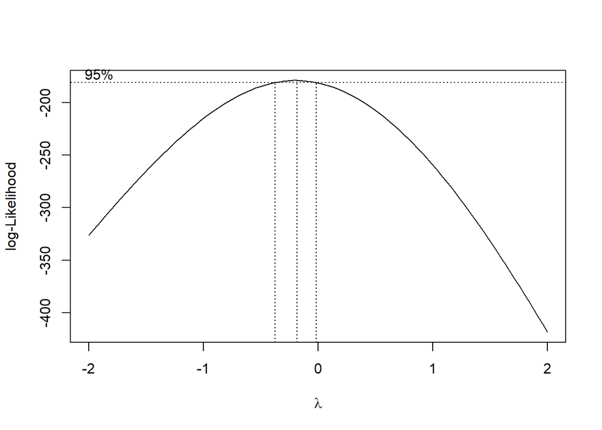

Let’s attempt to transform Y using a logarithm transformation.

```r
inf_mod4 = lm(log(mortality) ~ ., data = infmort)
summary(inf_mod4)
```

```
##
## Call:
## lm(formula = log(mortality) ~ ., data = infmort)
##
## Residuals:
##      Min       1Q   Median       3Q      Max
## -1.63943 -0.32722  0.03984  0.30077  2.28450
##
## Coefficients:
##                     Estimate Std. Error t value Pr(>|t|)
## (Intercept)        5.383e+00  2.373e-01  22.686  < 2e-16 ***
## regionEurope      -1.341e+00  2.451e-01  -5.469 3.65e-07 ***
## regionAsia        -8.294e-01  1.607e-01  -5.161 1.34e-06 ***
## regionAmericas    -8.377e-01  1.739e-01  -4.818 5.49e-06 ***
## income            -2.358e-04  5.906e-05  -3.993 0.000129 ***
## oilno oil exports -4.790e-01  2.306e-01  -2.077 0.040511 *
## ---
## Signif. codes:  0 '***' 0.001 '**' 0.01 '*' 0.05 '.' 0.1 ' ' 1
##
## Residual standard error: 0.6171 on 95 degrees of freedom
##   (4 observations deleted due to missingness)
## Multiple R-squared:  0.6142, Adjusted R-squared:  0.5939
## F-statistic: 30.25 on 5 and 95 DF,  p-value: < 2.2e-16
```

With that transformation, we see a large increase in both $R^2$ and $Adj. R^2$ compared to the previous two models. Also, all variables are now significant at least at $\alpha = .05$ which is great. One last model to try is with a log transformation on Y and a -log transformation on income.

```r
inf_mod5 = lm(log(mortality) ~ region + oil + I(-log(income)), data = infmort)
summary(inf_mod5)
```

```
##
## Call:
## lm(formula = log(mortality) ~ region + oil + I(-log(income)),
##     data = infmort)
##
## Residuals:
##     Min      1Q  Median      3Q     Max
## -1.4208 -0.3062 -0.0331  0.3091  2.4897
##
## Coefficients:
##                   Estimate Std. Error t value Pr(>|t|)
## (Intercept)        7.19231    0.44331  16.224  < 2e-16 ***
## regionEurope      -1.03383    0.25672  -4.027 0.000114 ***
## regionAsia        -0.71292    0.15757  -4.524 1.75e-05 ***
## regionAmericas    -0.54984    0.18449  -2.980 0.003657 **
## oilno oil exports -0.64021    0.22505  -2.845 0.005444 **
## I(-log(income))    0.33985    0.06658   5.104 1.70e-06 ***
## ---
## Signif. codes:  0 '***' 0.001 '**' 0.01 '*' 0.05 '.' 0.1 ' ' 1
##
## Residual standard error: 0.5908 on 95 degrees of freedom
##   (4 observations deleted due to missingness)
## Multiple R-squared:  0.6464, Adjusted R-squared:  0.6278
## F-statistic: 34.73 on 5 and 95 DF,  p-value: < 2.2e-16
```

Once again, we see an increase in $R^2$ and $Adj. R^2$ compared to the previous model. All variables are now significant at $\alpha = .01$ which is also awesome. This will be the last model created for modeling this data, as it performs well. It should be noted that outliers were not thought of to be considered for removal due to the nature of this problem. Having high mortality may seem to as an outlier theoretically, but in reality it is just a case of a high death area due to the war on oil.

## Problem 3.

Using the pulp data, determine whether there are any differences between the operators. What is the nature of these differences?

```r
pulp %>% group_by(operator) %>%
  summarise(mean_bright = mean(bright), median_bright = median(bright), sd_bright = sd(bright))
```

```
## # A tibble: 4 x 4
##   operator mean_bright median_bright sd_bright
##   <fct>          <dbl>         <dbl>     <dbl>
## 1 a               60.2          60       0.518
## 2 b               60.1          60       0.241
## 3 c               60.6          60.7     0.228
## 4 d               60.7          60.6     0.217
```

Looking at the group summary above, my initial thoughts is there is not a difference between the operators. The mean brightness for all operators are about the same, as well as the median and the standard deviations. It should be noted that operator **a** and **b** have slightly lower mean and medians than **c** and **d**. It should also be noted that **a** has a slightly higher standard deviation.

```r
mean(pulp$bright)
```

```
## [1] 60.4
```

The overall mean for **bright** between all operators is 60.4.

Let’s perform an ANOVA test to test the differences between operators.

```r
pulp_mod = lm(bright ~ operator, data = pulp)
anova(pulp_mod)
```

```
## Analysis of Variance Table
##
## Response: bright
##           Df Sum Sq Mean Sq F value  Pr(>F)
## operator   3   1.34 0.44667  4.2039 0.02261 *
## Residuals 16   1.70 0.10625
## ---
## Signif. codes:  0 '***' 0.001 '**' 0.01 '*' 0.05 '.' 0.1 ' ' 1
```

```r
pulp_mod2 = lm(bright ~ operator - 1, data = pulp)
summary(pulp_mod2)
```

```
##
## Call:
## lm(formula = bright ~ operator - 1, data = pulp)
##
## Residuals:
##    Min     1Q Median     3Q    Max
## -0.440 -0.195 -0.070  0.175  0.560
##
## Coefficients:
##           Estimate Std. Error t value Pr(>|t|)
## operatora  60.2400     0.1458   413.2   <2e-16 ***
## operatorb  60.0600     0.1458   412.0   <2e-16 ***
## operatorc  60.6200     0.1458   415.9   <2e-16 ***
## operatord  60.6800     0.1458   416.3   <2e-16 ***
## ---
## Signif. codes:  0 '***' 0.001 '**' 0.01 '*' 0.05 '.' 0.1 ' ' 1
##
## Residual standard error: 0.326 on 16 degrees of freedom
## Multiple R-squared:      1,  Adjusted R-squared:      1
## F-statistic: 1.717e+05 on 4 and 16 DF,  p-value: < 2.2e-16
```

Looking at the output above, we see that all operators have very similar coefficients as well as identical standard errors and almost identical t-values.

Let’s try using a different contrast matrix to further test for differences.

```r
operator = pulp$operator
bright = pulp$bright
contrasts(operator) = contr.sum(4)

pulp_mod3 = lm(bright ~ operator)
summary(pulp_mod3)
```

```
##
## Call:
## lm(formula = bright ~ operator)
##
## Residuals:
##    Min     1Q Median     3Q    Max
## -0.440 -0.195 -0.070  0.175  0.560
##
## Coefficients:
##             Estimate Std. Error t value Pr(>|t|)
## (Intercept) 60.40000    0.07289 828.681   <2e-16 ***
## operator1   -0.16000    0.12624  -1.267    0.223
## operator2   -0.34000    0.12624  -2.693    0.016 *
## operator3    0.22000    0.12624   1.743    0.101
## ---
## Signif. codes:  0 '***' 0.001 '**' 0.01 '*' 0.05 '.' 0.1 ' ' 1
##
## Residual standard error: 0.326 on 16 degrees of freedom
## Multiple R-squared:  0.4408, Adjusted R-squared:  0.3359
## F-statistic: 4.204 on 3 and 16 DF,  p-value: 0.02261
```

With changing the contrast matrix, the intercept is now the overall mean between all operators and the coefficients for operators a-c now represent the distance between their mean and the overall mean.

```r
anova(pulp_mod3)
```

```
## Analysis of Variance Table
##
## Response: bright
##           Df Sum Sq Mean Sq F value  Pr(>F)
## operator   3   1.34 0.44667  4.2039 0.02261 *
## Residuals 16   1.70 0.10625
## ---
## Signif. codes:  0 '***' 0.001 '**' 0.01 '*' 0.05 '.' 0.1 ' ' 1
```

We once again reject $H_0$ that the operators have no differences at $\alpha = .05$.

I can conclude that albeit small differences, there are differences between the operators in the pulp dataset.